# Manual de Ambientación de Servidor con PostgreSQL y pgAdmin utilizando Docker

Este manual tiene como objetivo guiar la configuración de un servidor con **PostgreSQL** y **pgAdmin**, colocando los contenedores en el directorio `/home` en lugar de `/root`.

**Requisitos previos:**

- El servidor debe contar con un sistema operativo linux funcional.
- El servidor debe de contar con internet para la instalación de docker
- Debes conocer las credenciales del servidor para conectarte vía SSH o SCP.

# FASE 1: Actualización del Servidor e Instalación de Docker

### 1. Acceder al servidor vía SSH

Iniciamos sesión en el servidor para comenzar la configuración.

bash

```bash
# Conectarse al servidor por SSH usando el usuario y la IP correspondientes
ssh <usuario_servidor>@<ip_del_servidor>
```

**Ejemplo de uso:**

bash

```bash
ssh nominadbdev@30.0.0.97
```

### 2. Verificar la distribución de Linux instalada

Identificamos la distribución para seguir la guía de instalación adecuada.

bash

```bash
# Muestra detalles del sistema operativo actual
cat /etc/os-release
```

### 3. Actualizar el sistema operativo

Una vez identificada la distribución (por ejemplo, **Rocky Linux 9.5**, compatible con RHEL/CentOS), se debe ejecutar el comando de actualización correspondiente. En el caso de Rocky/CentOS/RHEL, se utiliza `dnf`.

bash

```bash
# Actualiza todos los paquetes del sistema operativo
sudo dnf update
```

### 4. Reiniciar el servidor tras la actualización

Una vez finalizada la actualización del sistema, es recomendable reiniciar para asegurar que todos los cambios se apliquen correctamente. Esperar unos minutos antes de volver a ingresar via SSH

bash

```bash
# Reinicia el servidor
sudo reboot
```

### 5. Instalar Docker

La instalación debe seguir la guía oficial correspondiente a la distribución detectada.

- [Guía oficial de instalación de Docker para CentOS](https://docs.docker.com/engine/install/centos/)

> ⚠️ Se recomienda usar siempre las instrucciones oficiales para asegurar compatibilidad.

### 6. Verificar el estado del servicio Docker

En lugar de usar `hello-world`, que puede fallar por temas de red o restricciones del servidor, validamos directamente si el servicio Docker se encuentra en ejecución.

Al ejecutar el siguiente comando, el estado del servicio debe mostrarse en **color verde** con el mensaje `active (running)`. Si en cambio aparece en **rojo** o **blanco**, es probable que haya ocurrido un error durante la instalación y se recomienda revisar los pasos previos o consultar los logs del servicio.

bash

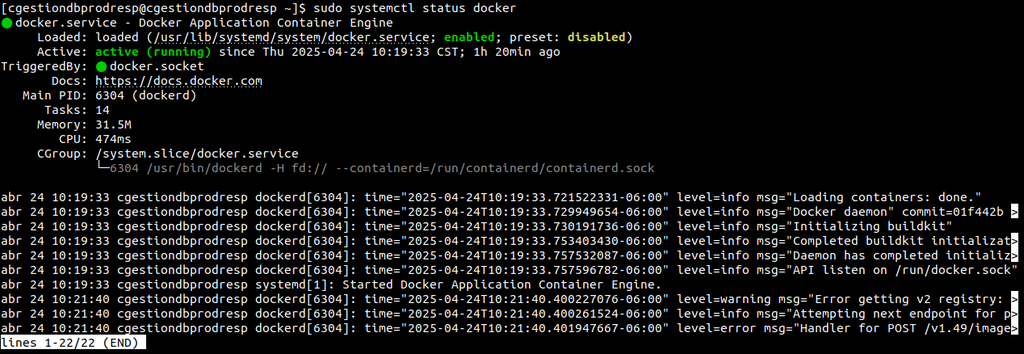

```bash
# Verifica si el servicio Docker está activo y en ejecución
sudo systemctl status docker
```

### 7. Configurar Docker para ejecutarse sin `sudo`

Se recomienda agregar el usuario actual al grupo `docker` para evitar anteponer `sudo` en cada comando.

bash

```bash
# Añade el usuario actual al grupo 'docker'
sudo usermod -aG docker ${USER}

# Inicia una nueva sesión para aplicar los cambios de grupo
su - ${USER}

# Muestra los grupos del usuario para confirmar que 'docker' fue agregado
groups
```

## FASE 2: Descarga de Imágenes y Transferencia al Servidor

### 8. Descarga de imágenes desde Docker Hub

Debido a que el servidor puede presentar restricciones de red (como puertos bloqueados o acceso limitado a internet), se recomienda realizar la descarga de las imágenes necesarias desde una **computadora local** que tenga acceso completo a la red.

Para descargar correctamente las imágenes, primero se debe identificar la versión deseada en [Docker Hub](https://hub.docker.com/), y posteriormente utilizar el comando `docker pull` desde la terminal.

- **PostgreSQL:** Buscar “postgres” en [Docker Hub](https://hub.docker.com/) y seleccionar la que tiene la etiqueta **Docker Official Image**.
- **pgAdmin:** Acceder a la [página oficial](https://www.pgadmin.org/download/pgadmin-4-container/), seleccionar “Docker Hub” y descargar desde [este enlace](https://hub.docker.com/r/dpage/pgadmin4/), ya que **no cuenta con la etiqueta de imagen oficial**.

Al ejecutar `docker pull` sin especificar versión, se descargará automáticamente la **última versión disponible** de la imagen. Si se desea una versión específica, es necesario indicarla explícitamente siguiendo el formato `<imagen>:<versión>`, según la lista de etiquetas disponibles en Docker Hub.

bash

```bash
# Descarga la imagen desde Docker Hub
docker pull <imagen>
```

**Ejemplo de uso:**

bash

```bash
# Descargar la imagen oficial de postgres 17.4 desde Docker Hub
docker pull postgres:17.4

# Descargar la imagen oficial de pgAdmin desde Docker Hub
docker pull dpage/pgadmin4
```

### 9. Exportar las imágenes a archivos `.tar`

Esto permite trasladar las imágenes al servidor sin conexión a internet.

bash

```bash
# Guarda la imagen en un archivo .tar
docker save -o <nombre_archivo>.tar <nombre_o_id_imagen>

# Verificar los archivos creados
ls
```

**Ejemplo de uso:**

bash

```bash
# Guarda la imagen de postgres en un archivo .tar
docker save -o postgres17-4.tar postgres:17.4

# Guarda la imagen de pgadmin en un archivo .tar
docker save -o pgadmin.tar dpage/pgadmin4
```

### 10. Transferir archivos `.tar` al servidor

Utilizar `scp` o herramientas como FileZilla para subir los archivos al directorio `/home/usuario` del servidor.

bash

```bash
# Envía los archivos .tar al servidor vía SCP
scp <archivo>.tar <usuario>@<ip_del_servidor>:/home/<usuario>/
```

**Ejemplo de uso:**

bash

```bash
# Envía el archivos postgres17-4.tar al servidor vía SCP
scp postgres17-4.tar nominadbdev@30.0.0.97:/home/nominadbdev

# Envía el archivos pgadmin.tar al servidor vía SCP
scp pgadmin.tar nominadbdev@30.0.0.97:/home/nominadbdev
```

## FASE 3: Cargar imagenes al docker

### 11. Acceder al servidor y realizar validaciones básicas

Inicia sesión en el servidor y verifica:

- Que los archivos `.tar` estén presentes.
- Que Docker esté instalado.
- Que el servicio de Docker esté activo.
- Que haya suficiente espacio disponible en disco.

bash

```bash
# Conectarse al servidor por SSH
ssh <usuario_servidor>@<ip_del_servidor>

# Verificar si esta el .tar
ls

# Verificar espacio disponible
df -lh

# Verificar instalación de Docker
docker --version

# Verifica que el servicio de Docker esté activo
sudo systemctl status docker
```

**Ejemplo de uso:**

bash

```bash
ssh nominadbdev@30.0.0.97
```

### 12. Cargar imágenes al Docker del servidor

Es recomendable cargar una imagen a la vez y luego continuar con el paso 13 antes de subir la siguiente.

Al subir la imagen a Docker, esta no tiene nombre ni etiqueta por defecto. Por ello, se recomienda realizar el proceso de una en una para evitar confusiones al asignar nombre y tag (ver paso 13).

bash

```bash
# Carga la imagen de PostgreSQL en Docker desde el archivo .tar
docker load -i <archivo.tar>
```

**Ejemplo de uso:**

bash

```bash
# Carga la imagen de postgres en Docker desde el archivo .tar
docker load -i postgres17-4.tar

# Carga la imagen de pgAdmin en Docker desde el archivo .tar
docker load -i pgadmin.tar
```

### 13. Renombrar etiquetas (tags) de imágenes

Al cargar las imágenes, es posible que aparezcan como `<none>`. Es importante asignar un nombre y etiqueta adecuados para facilitar su uso.

bash

```bash
# Lista las imágenes disponibles y sus IDs
docker images

# Cambia el tag de una imagen usando su ID
docker tag <id_imagen> <nombre>:<etiqueta>
```

**Ejemplo de uso:**

bash

```bash
# Cambiar el nombre y etiqueta de postgres
docker tag f49abb9855df postgres:17.4

# Cambiar el nombre y etiqueta de pgadmin
docker tag 46af92358e2e pgadmin:4
```

### 14. Eliminar archivos `.tar` luego de cargar las imágenes a Docker

Una vez que las imágenes han sido correctamente cargadas en Docker, es buena práctica eliminar los archivos `.tar` para liberar espacio en disco.

bash

```bash
# Elimina el archivo .tar del directorio home una vez cargado en Docker
rm <archivo>.tar
```

**Ejemplo de uso:**

bash

```bash
# Cambiar el nombre y etiqueta de postgres
rm postgres17-4.tar

# Cambiar el nombre y etiqueta de pgadmin
rm pgadmin.tar
```

## FASE 4: Crear contenedores

### 15. Crear estructura de carpetas para organizar contenedores

Para mantener un control claro y ordenado de los archivos relacionados a cada contenedor, se recomienda crear una estructura de carpetas dentro del directorio `/home/usuario/`. Esto facilita la gestión cuando se tienen múltiples versiones o instancias de un mismo tipo de contenedor (por ejemplo, varias versiones de PostgreSQL).

**Estructura recomendada:**

command-block

```
/home/usuario/
├── contenedor-postgres
│   └── postgres-principal
└── contenedor-pgadmin
    └── pgadmin-principal
```

bash

```bash
# Crear carpeta principal para contenedores PostgreSQL
mkdir <ruta_carpeta>
```

**Ejemplo de uso:**

bash

```bash
mkdir /home/nominadbdev/contenedor-postgres
```

## 16. Asignar permisos a la carpeta de pgAdmin

Es importante asignar correctamente los permisos a la carpeta donde se almacenarán los datos de pgAdmin. Esto asegura que el contenedor tenga acceso adecuado a sus archivos.

bash

```bash
# Cambiar propietario de la carpeta a UID y GID 5050 (pgAdmin)
sudo chown -R 5050:5050 <ruta_de_carpeta>

# Asignar permisos de lectura, escritura y ejecución al propietario, y solo lectura y ejecución al grupo
sudo chmod -R 750 <ruta_de_carpeta>

# Verificar permisos de la carpeta
ls -ld <ruta_de_carpeta>
```

**Ejemplo de uso:**

bash

```bash
sudo chown -R 5050:5050 /home/nominadbdev/contenedor-pgadmin4/

sudo chmod -R 750 /home/nominadbdev/contenedor-pgadmin4/

ls -ld /home/nominadbdev/contenedor-pgadmin4/
```

El resultado debe ser similar a:

bash

```bash
drwxr-x--- 2 5050 5050 4096 Jul 10 12:00 <ruta_de_carpeta>
```

## 17. Crear los contenedores de PostgreSQL y pgAdmin

Vamos a crear los contenedores montando los volúmenes directamente en el directorio `/home` para un mejor control y aprovechamiento del espacio, en lugar del directorio raíz (`/root`).

Importante

Al indicar rutas de carpetas en los comandos (por ejemplo, al mapear volúmenes en Docker), **usa siempre la ruta completa** y evita utilizar abreviaciones como `~` para referirse al home del usuario.  
Esto ayuda a reducir errores relacionados con rutas no reconocidas o mal interpretadas por Docker o el sistema operativo.

bash

```bash
# Crear contenedor de PostgreSQL
docker run --name <nombre_contenedor> \
  -e POSTGRES_USER=<usuario_postgres> \
  -e POSTGRES_PASSWORD=<contraseña_postgres> \
  -p 5432:5432 \
  -v <ruta_carpeta_postgres>:/var/lib/postgresql/data \
  -d <nombre_imagen>:<etiqueta_imagen>
```

bash

```bash
# Crear contenedor de pgAdmin
docker run --name <nombre_contenedor> \
  -p 80:80 \
  -e 'PGADMIN_DEFAULT_EMAIL=<email_pg_admin>' \
  -e 'PGADMIN_DEFAULT_PASSWORD=<Contraseña_pgadmin>' \
  -v <ruta_carpeta_pgadmin>:/var/lib/pgadmin \
  -d <nombre_imagen>:<etiqueta_imagen>
```

**Ejemplos de uso:**

bash

```bash
docker run --name nominaDbDev \
  -e POSTGRES_USER=postgres \
  -e POSTGRES_PASSWORD=postgres \
  -p 5432:5432 \
  -v /home/nominadbdev/contenedor-postgresql/postgresql-principal:/var/lib/postgresql/data \
  -d postgres:17.4
```

bash

```bash
docker run --name pgnominadbdev \
  -p 80:80 \
  -e 'PGADMIN_DEFAULT_EMAIL=admin@admin.com' \
  -e 'PGADMIN_DEFAULT_PASSWORD=admin.123' \
  -v /home/nominadbdev/contenedor-pgadmin4/pgadmin-principal:/var/lib/pgadmin \
  -d pgadmin:4
```

## 18. Verificar que los contenedores estén funcionando

Es crucial asegurarse de que los contenedores estén corriendo al menos 10 segundos y que sus logs no presenten errores. Esta verificación permite confirmar que el contenedor no se detiene inmediatamente por una mala configuración o error de ejecución.

El tiempo que lleva activo un contenedor puede observarse en la **columna STATUS** que aparece al ejecutar el comando `docker ps`. Si el contenedor ha estado “Up” por más de unos segundos, indica que se encuentra estable.

bash

```bash
# Mostrar contenedores activos
docker ps

# Ver logs del contenedor
docker logs <nombre_contenedor>
```

**Ejemplo de uso:**

bash

```bash
docker logs nominaDbDev
```

## 19. Conectar los contenedores a una red común

Esto permite que pgAdmin pueda comunicarse con PostgreSQL.

bash

```bash
# Crear una red personalizada
docker network create <nombre_network>

# Inspeccionar la red
docker network inspect <nombre_network>

# Conectar los contenedores a la red
docker network connect <nombre_network> <nombre_contenedor>
```

**Ejemplo de uso:**

bash

```bash
docker network create rednomina

docker network inspect  redgestion

# Conectar el contenedor de postgres
docker network connect redgestion nominaDbDev

# Conectar el contenedor de pgadmin
docker network connect redgestion pgnominadbdev
```

## 20. Establecer reinicio automático de contenedores

Esto permite configurar todos los contenedores en ejecución para que se reinicien automáticamente si el servidor se reinicia o el contenedor falla.

bash

```bash
# Establece la política de reinicio automático en todos los contenedores en ejecución
docker update --restart unless-stopped $(docker ps -q)
```

ó

bash

```bash
# Establece la política de reinicio automático 1 por 1
docker update --restart unless-stopped <id_contenedor>
```

Para estar más seguros, se pueden ejecutar ambos comandos.

## 21. Acceder a pgAdmin y registrar PostgreSQL

Desde un navegador web, acceder a la IP del servidor donde se encuentra desplegado pgAdmin. Una vez cargada la interfaz, iniciar sesión utilizando las credenciales configuradas al momento de crear el contenedor de pgAdmin. Estas credenciales corresponden a los valores de las variables de entorno:

- **Email:** el valor asignado a `PGADMIN_DEFAULT_EMAIL`
- **Password:** el valor asignado a `PGADMIN_DEFAULT_PASSWORD`

Estas variables se definieron durante la ejecución del comando `docker run` al crear el contenedor de pgAdmin.

1. Hacer clic derecho en “Servers” > **Register** > **Server**.

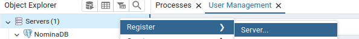

2. En la pestaña **General**, colocar un nombre identificador para el servidor. Se recomienda usar un nombre descriptivo que ayude a identificarlo fácilmente.

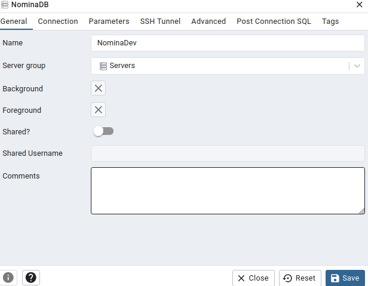

3. En la pestaña **Connection**, ingresar los siguientes datos del contenedor de PostgreSQL:
   - **Host name/address:** debe ser el **nombre del contenedor de PostgreSQL** (el que se indicó con el parámetro `--name` al momento de crearlo).
   - **Username:** el valor de `POSTGRES_USER` usado en la creación del contenedor.
   - **Password:** el valor de `POSTGRES_PASSWORD` usado en la creación del contenedor.

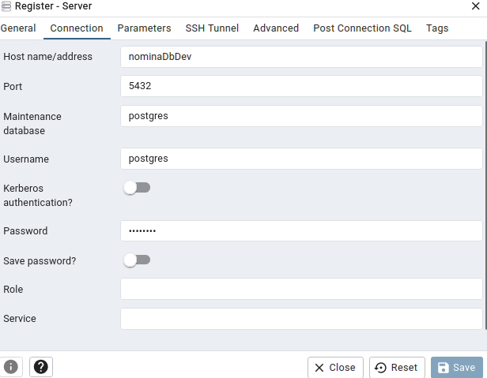

4. Marcar la opción *Save Password* para evitar tener que ingresarla cada vez y presionar **Save** para finalizar.

## ¡Listo! Con esto queda finalizado el despliegue de PostgreSQL y pgAdmin en tu servidor con Docker.